# Social Norms Meta

07 marzo, 2022

# Analysis Treatment-level: All Games

## HP1: Relation between norms and actions

#### *Are norms and cooperation behavior related?*

The content of the norm and behavior correlate positively.

Number of papers: 15.

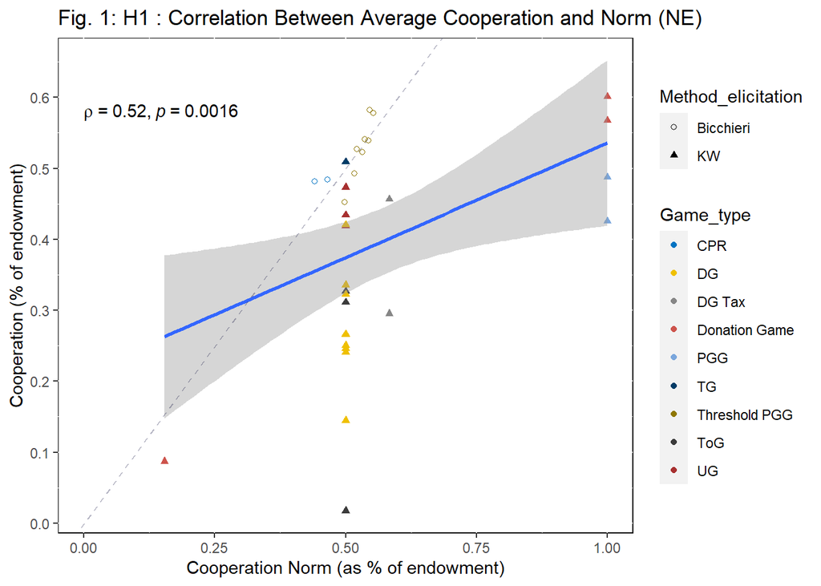

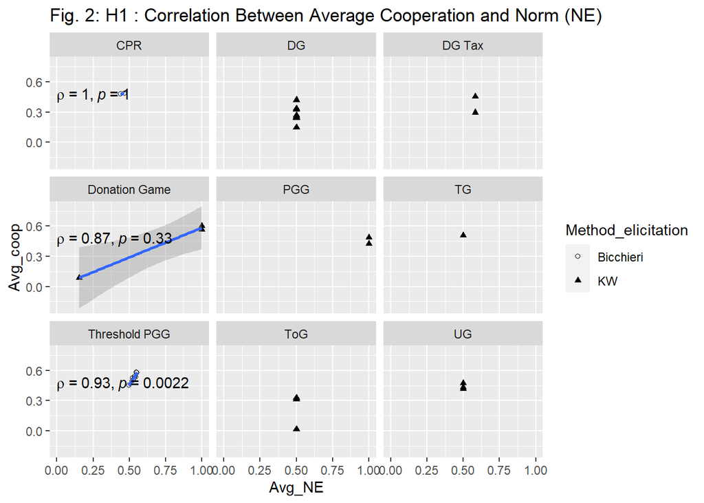

### Results

- Evidence from testing H1 shows that there is a positive and significant correlation between social expectations and cooperative behavior (Fig. 1).

## HP2 : Is compliance related to norm strength?

## Summary of computed variables

### DELTA ANALYSIS

We compute **Compliance** as

- $Delta = \frac{NE_{avg}-Coop_{avg}}{NE_{avg}}$

```
    Min.  1st Qu.   Median     Mean  3rd Qu.     Max.     NA's
-0.09164  0.02597  0.33797  0.28182  0.48768  0.96522        6
```

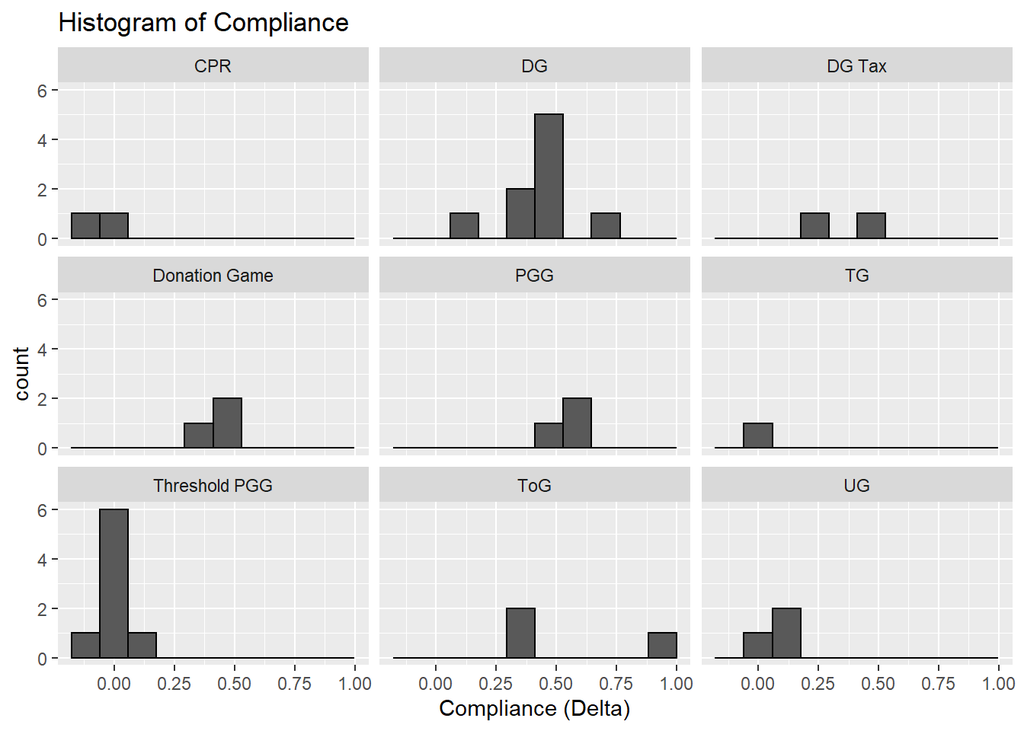

### STRENGTH OLD ANALYSIS

We compute norm strength as:

$$Strength = {NE_{Consistency}+NE_{Specificity}}$$

where:

**Specificity** indicates how appropriate is prevailing social norm relative to other possible action

- $NE_{Specificity} = \frac{1}{\sigma_j}$ $\forall KW_j$ is the reciprocal of the standard deviation computed on Krupka-Weber average appropriateness scores across all actions j

**Consistency** indicates what it is the consensus around a prevailing social norm

- $NE_{Consistency} = {1 \over \sigma_{N}}$ is the reciprocal of the standard deviation computed on the most appropriate action N

#### Norm Strength

```
   Min. 1st Qu.  Median    Mean 3rd Qu.    Max.    NA's
  3.708   4.180   4.692   4.823   5.222   6.967      13
```

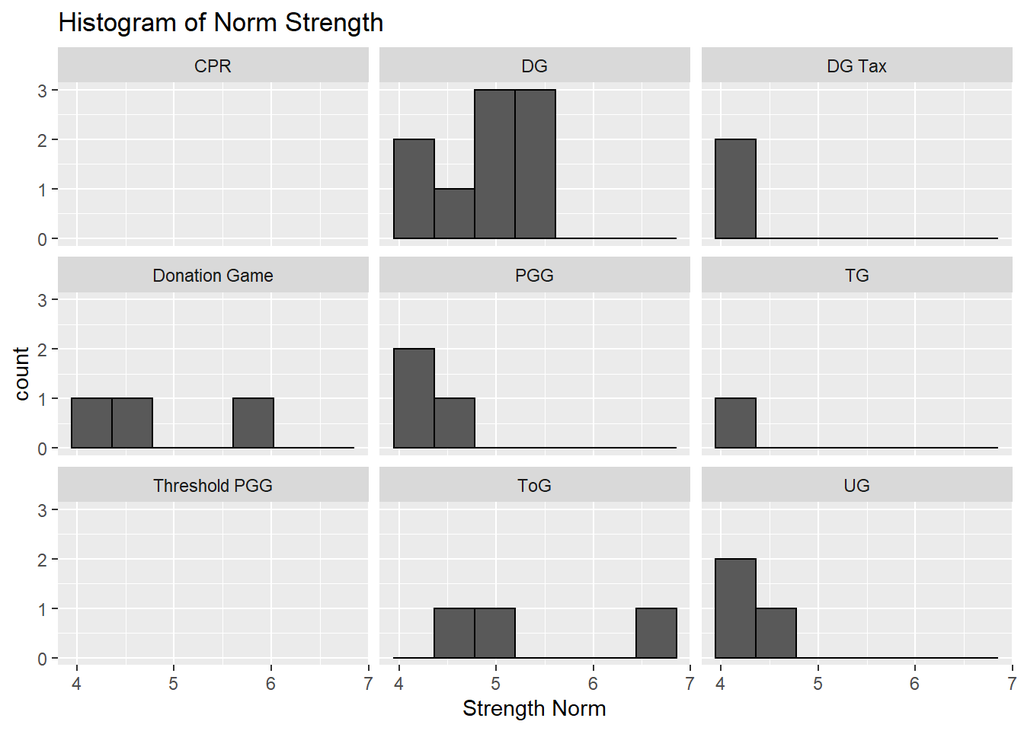

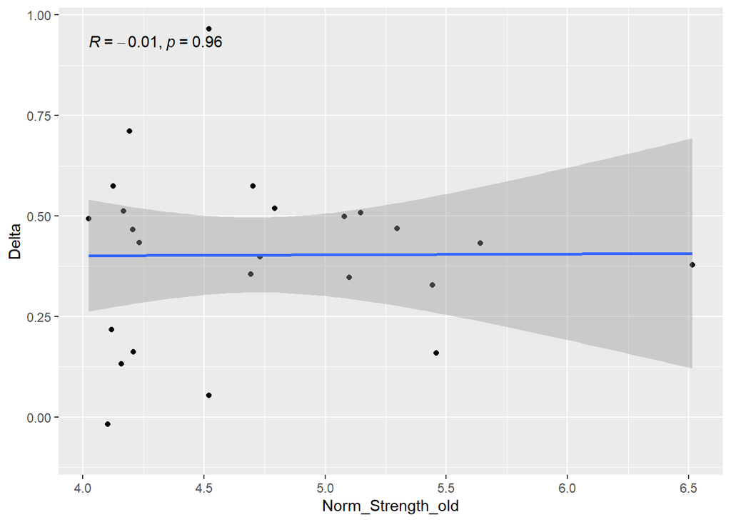

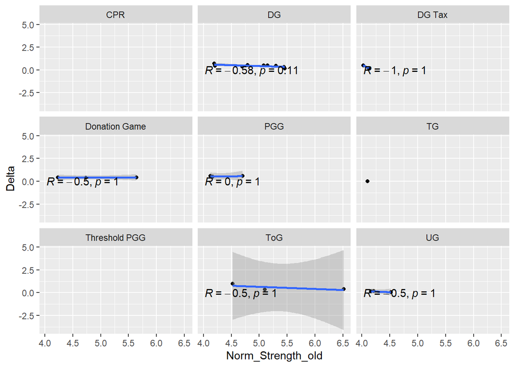

#### Specificity_old

```
Length  Class   Mode
     0   NULL   NULL
```

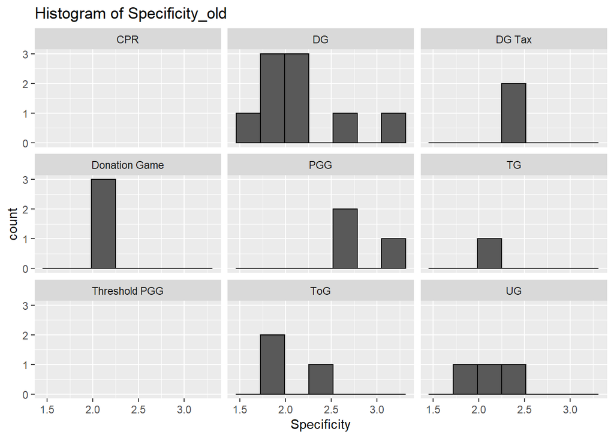

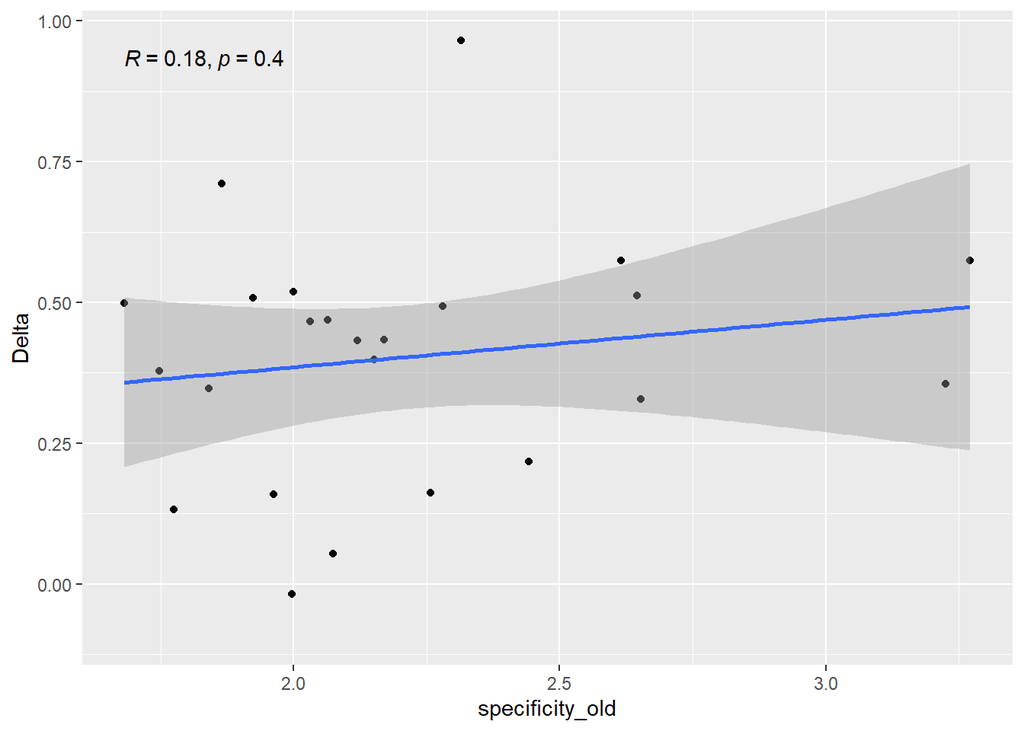

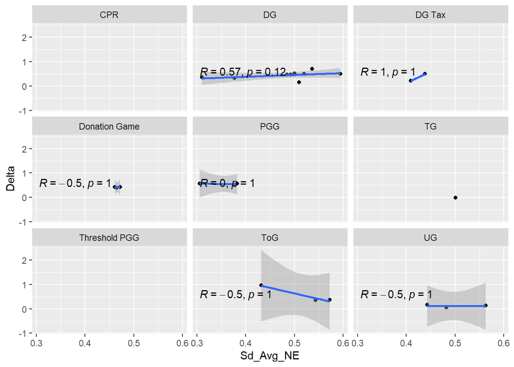

#### consistency_old

```
   Min. 1st Qu.  Median    Mean 3rd Qu.    Max.    NA's
 0.7326  1.5081  2.1068  2.2899  2.7927  5.2812       3
```

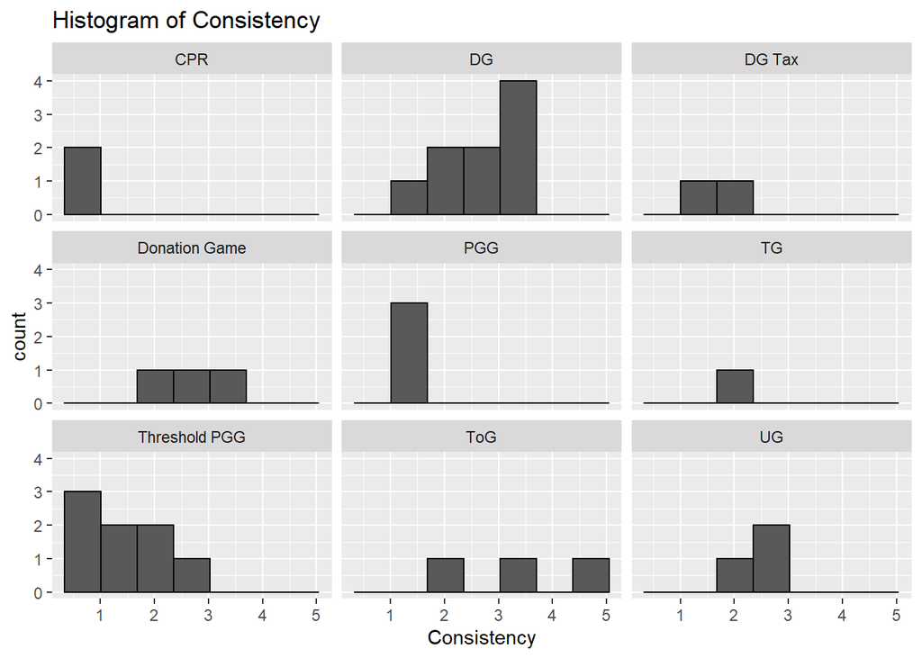

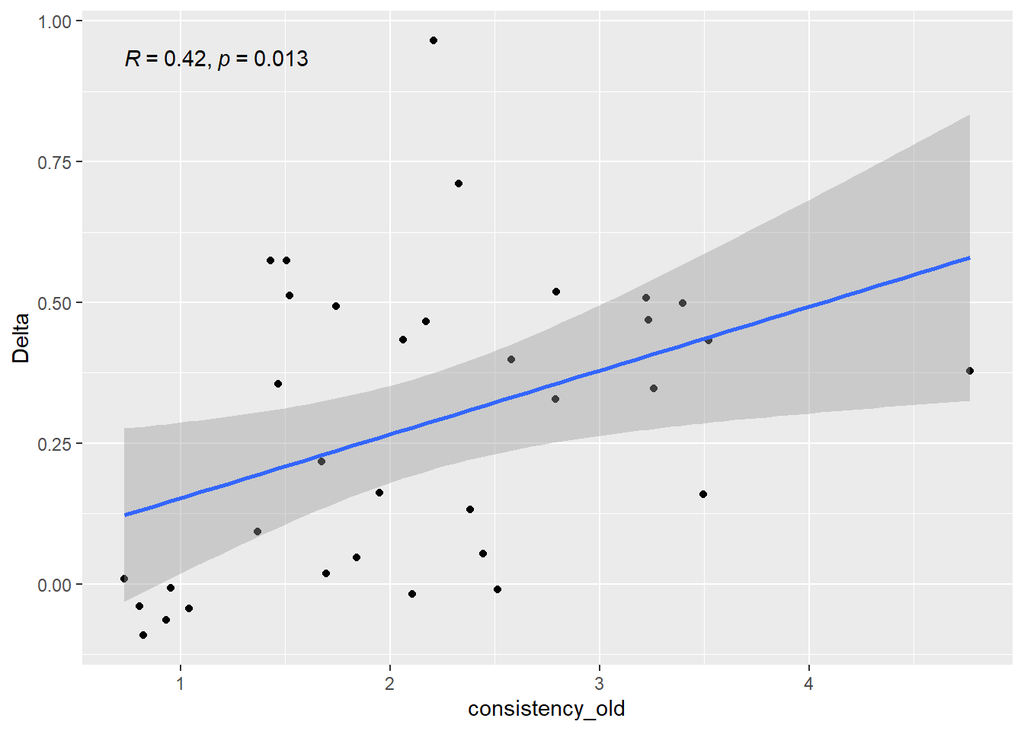

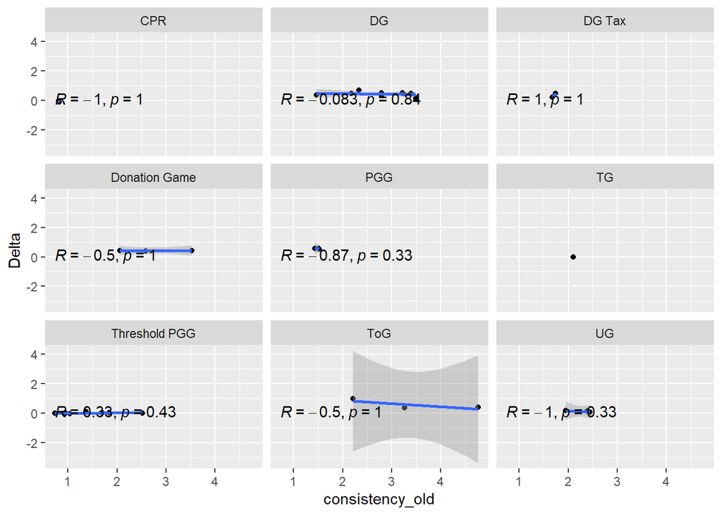

### STRENGTH NEW ANALYSIS

**Overview of the computed statistics**

$$Strength = {NE_{Consistency}+NE_{Specificity^+}}$$

$0 < Strength < 2$

where:

**Specificity** indicates how appropriate is the prevailing social norm relative to other possible action

- $NE_{Specificity^+} = \frac{{\sum_{i=1}^{N-1} max(KW)-KW_i}}{(N-1)}$ $\forall KW_i > 0$

We also computed the specificity for inappropriate actions (this is not used in the computation of norm strenght)

- $NE_{Specificity^-} = \frac{{\sum_{i=1}^{N-1} max(|KW|)-|KW|_i}}{(N-1)}$ $\forall KW_i < 0$

**Consistency** indicates what it is the consensus around a prevailing social norm

- $NE_{Consistency} = 1- {\sigma_{N} \over max(\sigma_{N})}$

**Content** indicates the mean appropriateness level of a norm.

- $E[max_j(KW_j)] \forall j \in A$ where A is the action space

#### Norm Strenght

```
   Min. 1st Qu.  Median    Mean 3rd Qu.    Max.    NA's
 0.4155  0.8101  1.0098  1.0149  1.2124  1.4900      13
```

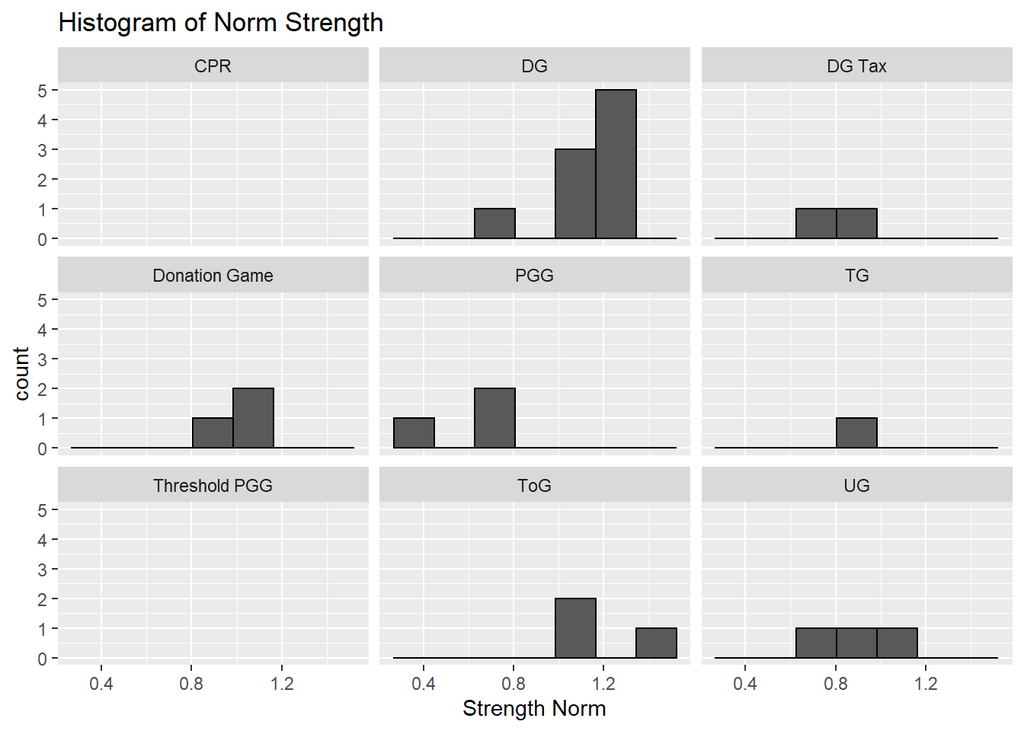

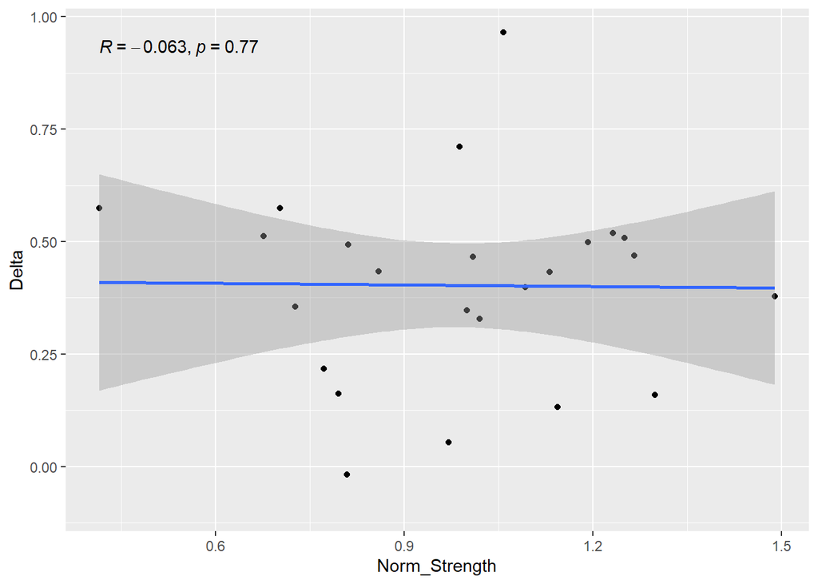

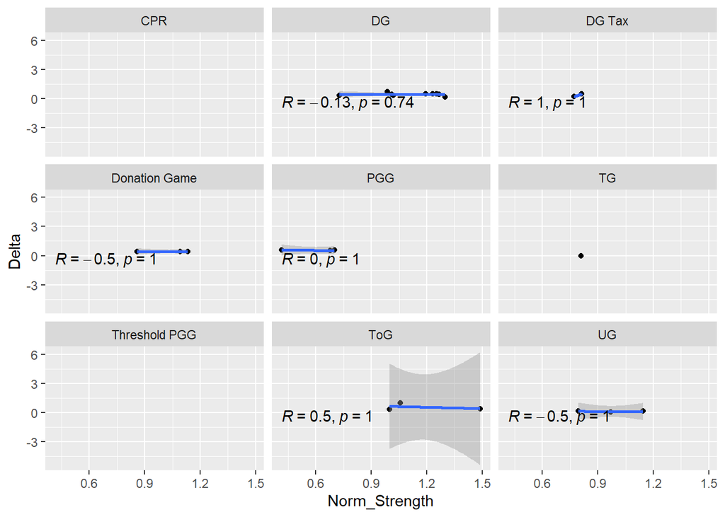

#### Specificity plus

```
   Min. 1st Qu.  Median    Mean 3rd Qu.    Max.    NA's
 0.1096  0.3506  0.4123  0.4379  0.5593  0.6985      13
```

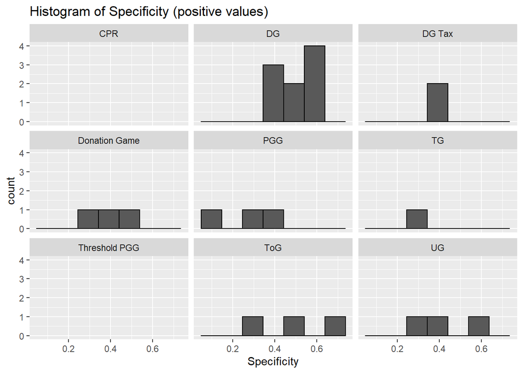

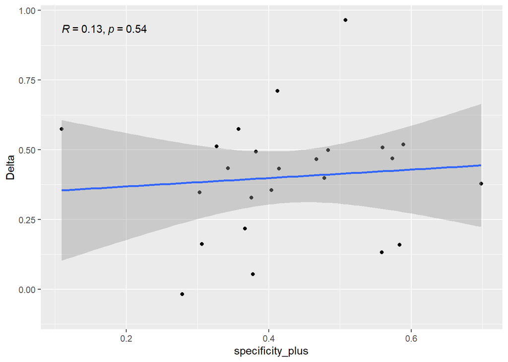

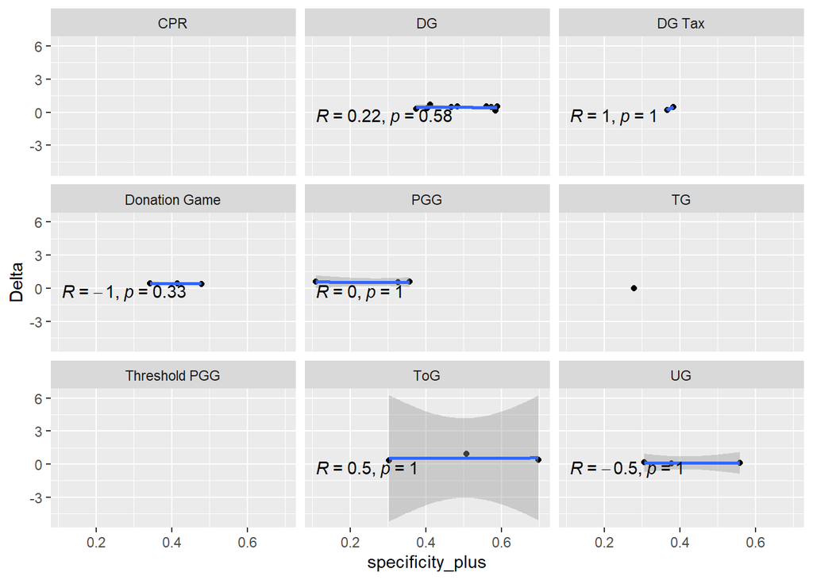

#### Consistency

```
   Min. 1st Qu.  Median    Mean 3rd Qu.    Max.    NA's
 0.3059  0.5029  0.5849  0.5770  0.6941  0.8133      13
```

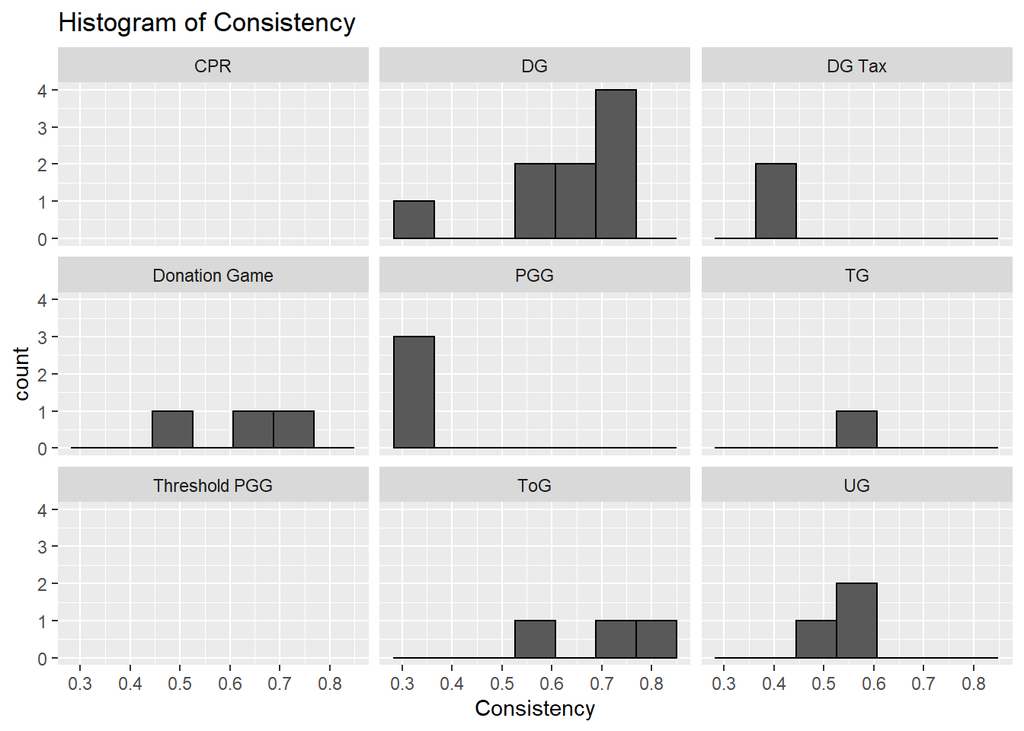

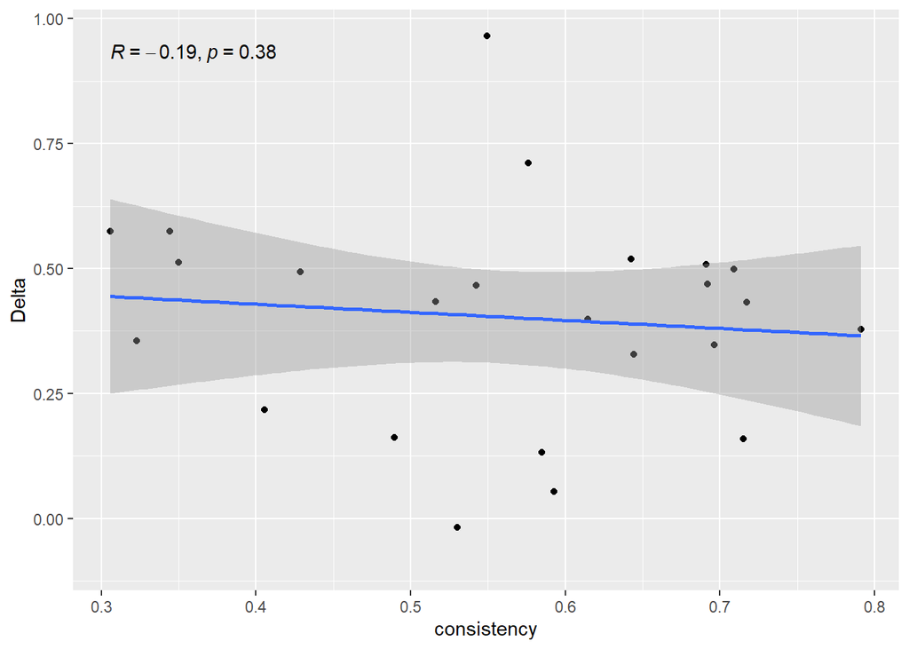

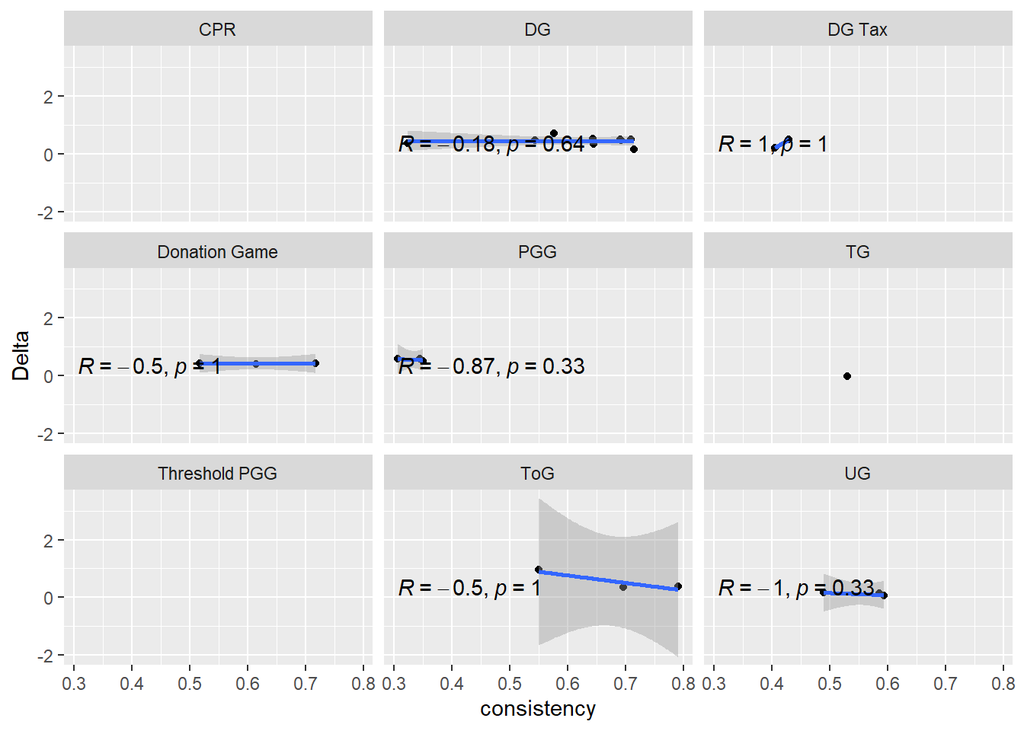

#### Norm Content

```
   Min. 1st Qu.  Median    Mean 3rd Qu.    Max.    NA's
 0.5257  0.6838  0.7872  0.7584  0.8484  0.9429      13
```

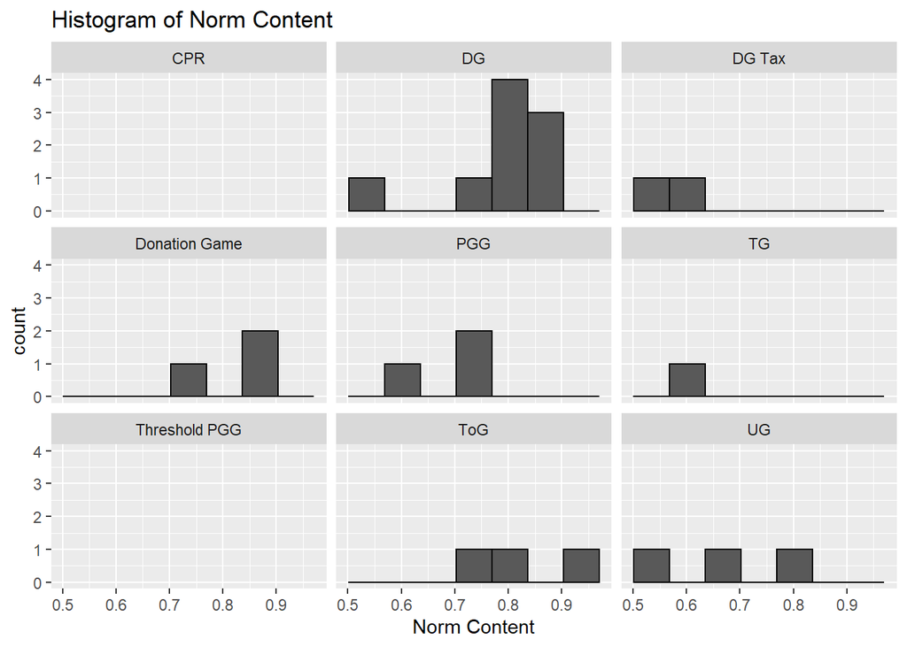

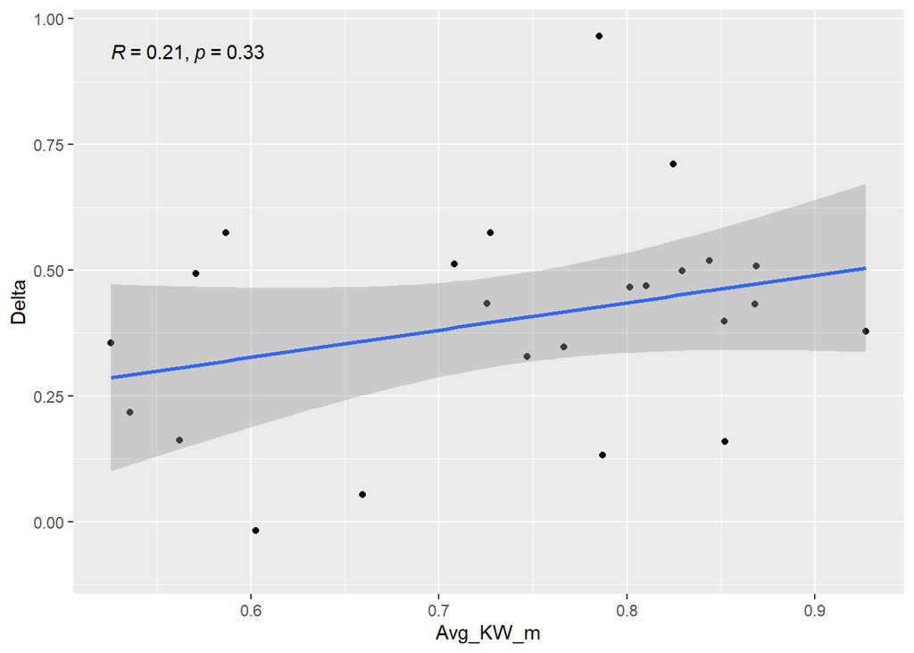

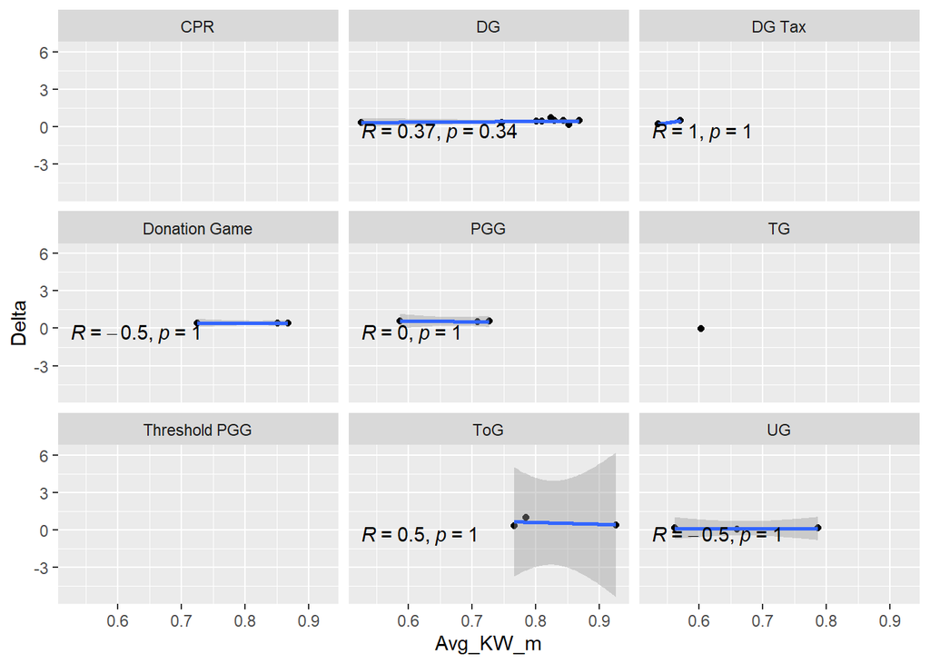

#### Relation among variables

** Norm Content and Specificity plus **

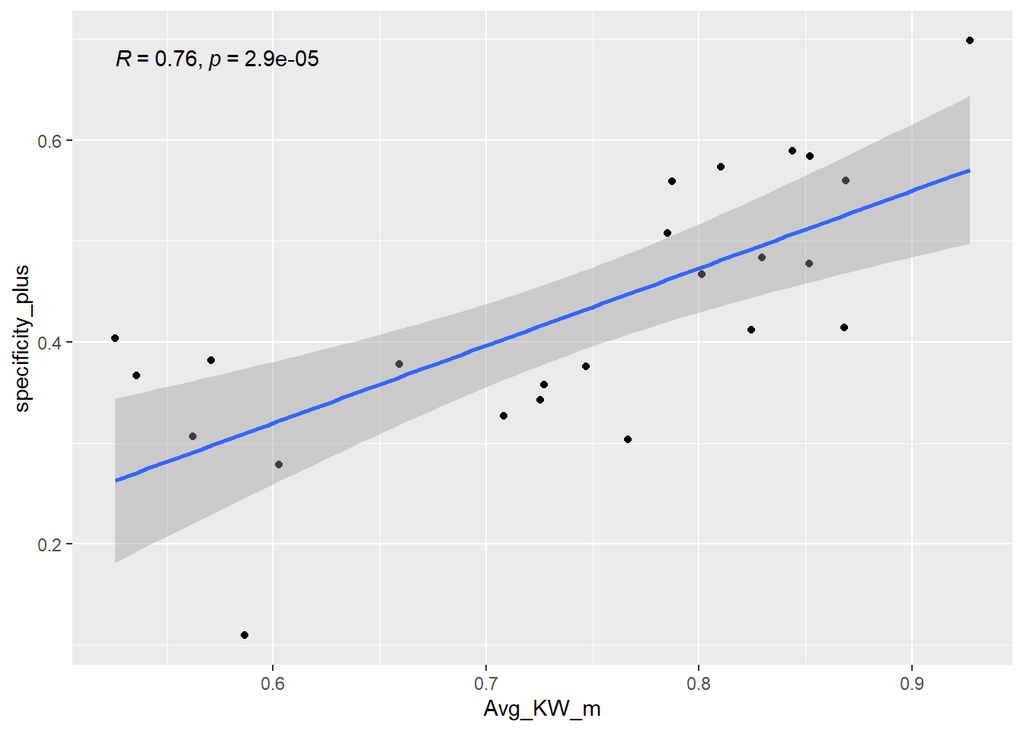

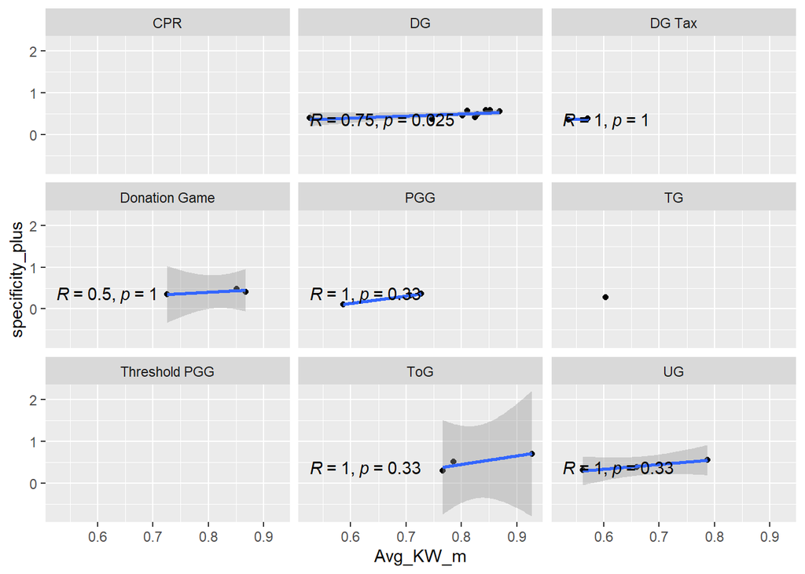

** Norm Content and Consistency **

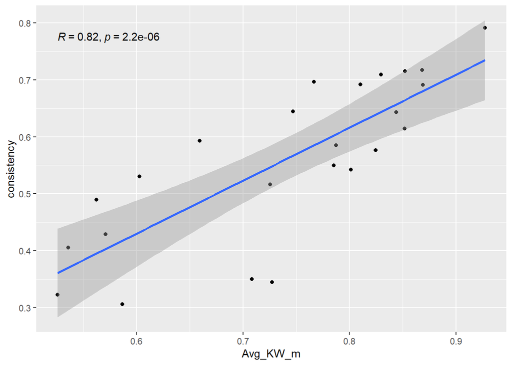

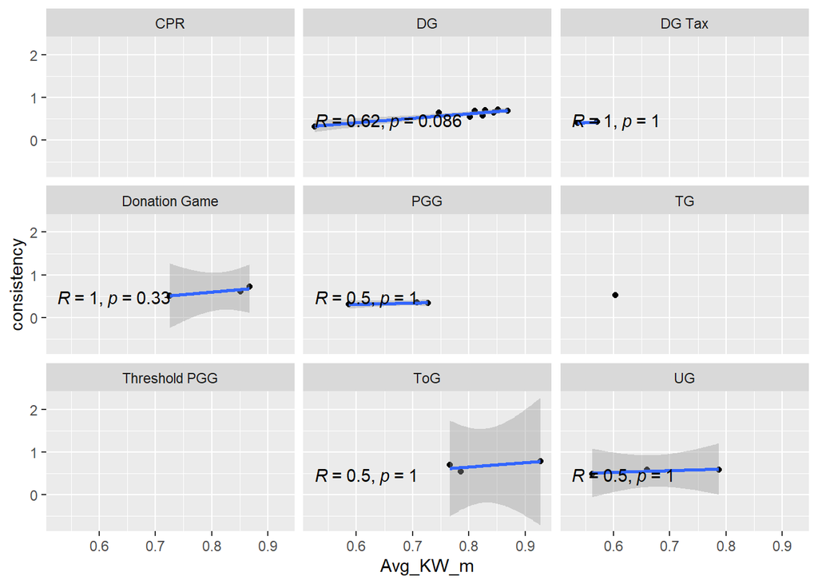

#### Delta vs Spec. neg.

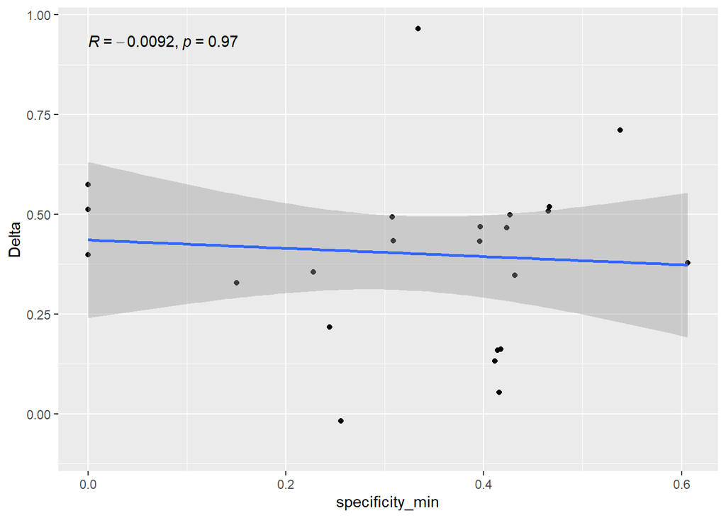

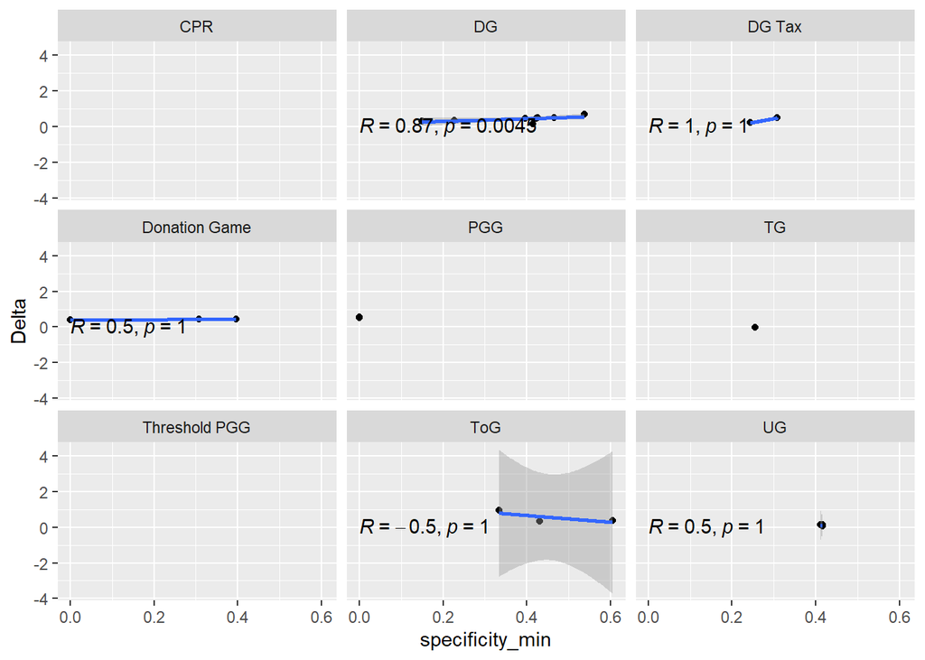

## HP3: Effect of punishment on norms and actions

### Cooperation, Delta and Strength Comparison between DG and UG

We test the hypothesis whether :

- **Cooperation** ($Coop_{avg}$) in DG is lower than UG.
  - The p-value of Mann-Whitney-Wilcoxon Test is 0.011, therefore we *can* reject the null hypothesis (at .05 significance level).
- **Delta** in DG is higher than UG.
  - The p-value of Mann-Whitney-Wilcoxon Test is 0.0182, therefore we *can* reject the null hypothesis (at .05 significance level).
- **Norm Strength** in DG is higher than UG.
  - The p-value of Mann-Whitney-Wilcoxon Test is 0.8981, therefore we *can’t* reject the null hypothesis (at .05 significance level).

Average and Mann-Whitney-Wilcoxon Test

| Game_type | Coop | Avg_Norm | Delta | Strength | n |
| --- | --- | --- | --- | --- | --- |
| DG | 0.2680 | 0.5 | 0.4461 | 1.1094 | 11 |
| UG | 0.4421 | 0.5 | 0.1158 | 0.9702 | 3 |
| Difference (M.W.W. p-value) | 0.0110 |  | 0.0182 | 0.8981 |  |

Consistency e Specificity

| Game_type | Specificity_plus | Specificity_min | Consistency |
| --- | --- | --- | --- |
| DG | 0.4943 | 0.3898 | 0.6151 |
| UG | 0.4961 | 0.4279 | 0.6532 |
| Difference (Wilcoxon p-value) | 1.0000 | 1.0000 | 0.7972 |

# Individual-level analysis

## Standard Utility framework

Here we estimate a random utility model using a conditional logit model (McFadden 1975). We split our individual-level analysis into 2 steps:

1. *Within subject design belief elicitation*: we estimate the utility function when beliefs and actions are elicited for the same subject
2. *Between subject design belief elicitation*: we estimate the utility function when beliefs and actions are elicited using distinct subjects

For 1., the model we estimate is the following:

$U_{ij} = \alpha \pi_j + \beta S_{ij}$

while for 2., we use $S_j=\Sigma S_{ij}/N$ from the external sample with which social norms were elicited. Hence the model becomes:

$U_{ij} = \alpha \pi_j + \beta S_{j}$

### Within-subjects Design

#### 2020Bas115

DG - Treatment 1 (“Social”)

```
Call:
coxph(formula = Surv(rep(1, 1353L), A) ~ payoff + KW_Normative +
    strata(subject_id), data = Bas115_dg %>% subset.data.frame(subset = treatment_id ==
    "2020Bas115_1a"), method = "exact")

  n= 1353, number of events= 123

                coef exp(coef) se(coef)      z Pr(>|z|)
payoff        0.7632    2.1452   0.1089  7.009  2.4e-12 ***
KW_Normative  3.3497   28.4934   0.3270 10.243  < 2e-16 ***
---
Signif. codes:  0 '***' 0.001 '**' 0.01 '*' 0.05 '.' 0.1 ' ' 1

             exp(coef) exp(-coef) lower .95 upper .95
payoff           2.145     0.4662     1.733     2.656
KW_Normative    28.493     0.0351    15.010    54.089

Concordance= 0.865  (se = 0.021 )
Likelihood ratio test= 232.8  on 2 df,   p=<2e-16
Wald test            = 116  on 2 df,   p=<2e-16
Score (logrank) test = 177.2  on 2 df,   p=<2e-16
```

DG - Treatment 2 (“Private”)

```
Call:
coxph(formula = Surv(rep(1, 1397L), A) ~ payoff + KW_Normative +
    strata(subject_id), data = Bas115_dg %>% subset.data.frame(subset = treatment_id ==
    "2020Bas115_2a"), method = "exact")

  n= 1397, number of events= 127

                coef exp(coef) se(coef)     z Pr(>|z|)
payoff       0.66931   1.95288  0.09349 7.159 8.14e-13 ***
KW_Normative 1.72083   5.58917  0.27691 6.214 5.15e-10 ***
---
Signif. codes:  0 '***' 0.001 '**' 0.01 '*' 0.05 '.' 0.1 ' ' 1

             exp(coef) exp(-coef) lower .95 upper .95
payoff           1.953     0.5121     1.626     2.346
KW_Normative     5.589     0.1789     3.248     9.617

Concordance= 0.769  (se = 0.021 )
Likelihood ratio test= 127.9  on 2 df,   p=<2e-16
Wald test            = 51.42  on 2 df,   p=7e-12
Score (logrank) test = 82.59  on 2 df,   p=<2e-16
```

UG - Treatment 1 (“Social”)

```
Call:
coxph(formula = Surv(rep(1, 660L), A) ~ payoff + KW_Normative +
    strata(subject_id), data = Bas115_ug %>% subset.data.frame(subset = treatment_id ==
    "2020Bas115_1c"), method = "exact")

  n= 660, number of events= 60

                 coef exp(coef) se(coef)      z Pr(>|z|)
payoff       -0.26614   0.76633  0.09456 -2.815  0.00488 **
KW_Normative  2.93745  18.86758  0.39863  7.369 1.72e-13 ***
---
Signif. codes:  0 '***' 0.001 '**' 0.01 '*' 0.05 '.' 0.1 ' ' 1

             exp(coef) exp(-coef) lower .95 upper .95
payoff          0.7663      1.305    0.6367    0.9224
KW_Normative   18.8676      0.053    8.6378   41.2125

Concordance= 0.853  (se = 0.03 )
Likelihood ratio test= 102.7  on 2 df,   p=<2e-16
Wald test            = 54.92  on 2 df,   p=1e-12
Score (logrank) test = 84.05  on 2 df,   p=<2e-16
```

UG - Treatment 2 (“Private”)

```
Call:
coxph(formula = Surv(rep(1, 693L), A) ~ payoff + KW_Normative +
    strata(subject_id), data = Bas115_ug %>% subset.data.frame(subset = treatment_id ==
    "2020Bas115_2c"), method = "exact")

  n= 693, number of events= 63

                 coef exp(coef) se(coef)      z Pr(>|z|)
payoff       -0.10816   0.89749  0.06699 -1.614    0.106
KW_Normative  1.65941   5.25623  0.27210  6.098 1.07e-09 ***
---
Signif. codes:  0 '***' 0.001 '**' 0.01 '*' 0.05 '.' 0.1 ' ' 1

             exp(coef) exp(-coef) lower .95 upper .95
payoff          0.8975     1.1142    0.7871     1.023
KW_Normative    5.2562     0.1903    3.0836     8.960

Concordance= 0.735  (se = 0.039 )
Likelihood ratio test= 52.11  on 2 df,   p=5e-12
Wald test            = 42.27  on 2 df,   p=7e-10
Score (logrank) test = 51.65  on 2 df,   p=6e-12
```

### Between-subjects Design

#### 2016Kim003

For DG game

```
Call:
coxph(formula = Surv(rep(1, 1122L), A) ~ payoff + KW_Normative +
    strata(subject_id), data = Kim003_dg, method = "exact")

  n= 1122, number of events= 66

                coef exp(coef) se(coef)     z Pr(>|z|)
payoff        0.9523    2.5918   0.1647 5.783 7.35e-09 ***
KW_Normative  4.3492   77.4203   0.7953 5.469 4.54e-08 ***
---
Signif. codes:  0 '***' 0.001 '**' 0.01 '*' 0.05 '.' 0.1 ' ' 1

             exp(coef) exp(-coef) lower .95 upper .95
payoff           2.592    0.38584     1.877     3.579
KW_Normative    77.420    0.01292    16.288   367.989

Concordance= 0.817  (se = 0.024 )
Likelihood ratio test= 88.68  on 2 df,   p=<2e-16
Wald test            = 34.03  on 2 df,   p=4e-08
Score (logrank) test = 47.73  on 2 df,   p=4e-11
```

For UG game

```
Call:
coxph(formula = Surv(rep(1, 1139L), A) ~ payoff + KW_Normative +
    strata(subject_id), data = Kim003_ug, method = "exact")

  n= 1139, number of events= 67

                 coef exp(coef) se(coef)     z Pr(>|z|)
payoff         0.9555    2.5999   0.1605 5.954 2.62e-09 ***
KW_Normative   5.8296  340.2174   0.7187 8.112 4.99e-16 ***
---
Signif. codes:  0 '***' 0.001 '**' 0.01 '*' 0.05 '.' 0.1 ' ' 1

             exp(coef) exp(-coef) lower .95 upper .95
payoff             2.6   0.384625     1.898     3.561
KW_Normative     340.2   0.002939    83.182  1391.506

Concordance= 0.888  (se = 0.022 )
Likelihood ratio test= 152.1  on 2 df,   p=<2e-16
Wald test            = 96.07  on 2 df,   p=<2e-16
Score (logrank) test = 137.2  on 2 df,   p=<2e-16
```

#### 2018Her061

```
Call:
coxph(formula = Surv(rep(1, 418L), A) ~ payoff + KW_Normative +
    strata(subject_id), data = Her061, method = "exact")

  n= 418, number of events= 38

                 coef exp(coef) se(coef)     z Pr(>|z|)
payoff         1.8670    6.4689   0.5111 3.653 0.000259 ***
KW_Normative   4.9146  136.2670   1.6665 2.949 0.003187 **
---
Signif. codes:  0 '***' 0.001 '**' 0.01 '*' 0.05 '.' 0.1 ' ' 1

             exp(coef) exp(-coef) lower .95 upper .95
payoff           6.469   0.154586     2.376     17.61
KW_Normative   136.267   0.007339     5.198   3572.03

Concordance= 0.858  (se = 0.035 )
Likelihood ratio test= 67.01  on 2 df,   p=3e-15
Wald test            = 27.24  on 2 df,   p=1e-06
Score (logrank) test = 52.33  on 2 df,   p=4e-12
```

#### 2019Cha026

Treatment 1

```
Call:
coxph(formula = Surv(rep(1, 616L), A) ~ payoff + KW_Normative +
    strata(subject_id), data = Cha026 %>% subset.data.frame(treatment_id ==
    "2019Cha026_1"), method = "exact")

  n= 616, number of events= 56

                coef exp(coef) se(coef)     z Pr(>|z|)
payoff        0.4931    1.6374   0.1118 4.412 1.02e-05 ***
KW_Normative  3.1339   22.9626   0.6382 4.911 9.08e-07 ***
---
Signif. codes:  0 '***' 0.001 '**' 0.01 '*' 0.05 '.' 0.1 ' ' 1

             exp(coef) exp(-coef) lower .95 upper .95
payoff           1.637    0.61071     1.315     2.038
KW_Normative    22.963    0.04355     6.574    80.212

Concordance= 0.83  (se = 0.039 )
Likelihood ratio test= 44.41  on 2 df,   p=2e-10
Wald test            = 24.47  on 2 df,   p=5e-06
Score (logrank) test = 32.5  on 2 df,   p=9e-08
```

Treatment 2

```
Call:
coxph(formula = Surv(rep(1, 1023L), A) ~ payoff + KW_Normative +
    strata(subject_id), data = Cha026 %>% subset.data.frame(treatment_id ==
    "2019Cha026_2"), method = "exact")

  n= 1023, number of events= 93

                coef exp(coef) se(coef)     z Pr(>|z|)
payoff       0.38088   1.46357  0.07033 5.415 6.12e-08 ***
KW_Normative 2.08554   8.04891  0.46010 4.533 5.82e-06 ***
---
Signif. codes:  0 '***' 0.001 '**' 0.01 '*' 0.05 '.' 0.1 ' ' 1

             exp(coef) exp(-coef) lower .95 upper .95
payoff           1.464     0.6833     1.275      1.68
KW_Normative     8.049     0.1242     3.267     19.83

Concordance= 0.771  (se = 0.032 )
Likelihood ratio test= 51.71  on 2 df,   p=6e-12
Wald test            = 29.61  on 2 df,   p=4e-07
Score (logrank) test = 38.21  on 2 df,   p=5e-09
```

### All papers results

Estimated Parameters

| ID | t | game | alpha | beta | SE_alpha | SE_beta | endowment | MRS |
| --- | --- | --- | --- | --- | --- | --- | --- | --- |
| 2020Bas115 | 1 | DG | 0.76 | 3.35 | 0.11 | 0.33 | 10 | 8.78 |
| 2020Bas115 | 2 | DG | 0.67 | 1.72 | 0.09 | 0.28 | 10 | 5.14 |
| 2020Bas115 | 3 | UG | -0.27 | 2.94 | 0.09 | 0.40 | 10 | -22.07 |
| 2020Bas115 | 4 | UG | -0.11 | 1.66 | 0.07 | 0.27 | 10 | -30.68 |
| 2016Kim003 | 1 | DG | 0.95 | 4.35 | 0.16 | 0.80 | 16 | 9.13 |
| 2016Kim003 | 2 | UG | 0.96 | 5.83 | 0.16 | 0.72 | 16 | 12.20 |
| 2018Her061 | 1 | DG | 1.87 | 4.91 | 0.51 | 1.67 | 10 | 5.26 |
| 2019Cha026 | 1 | DG | 0.49 | 3.13 | 0.11 | 0.64 | 7.83269961977186 | 12.71 |
| 2019Cha026 | 2 | DG | 0.38 | 2.09 | 0.07 | 0.46 | 10 | 10.95 |
| Average |  |  | 0.63 | 3.33 | 0.15 | 0.62 |  | 10.51 |

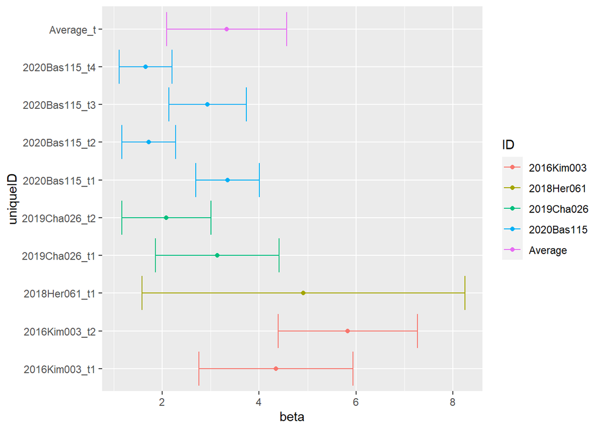

## Augmented Utility framework

Here we augment the standard utility framework by including a measure of norm specificity either at the individual level and at the choice level depending on the nature of the data (between-subject elicitation or within-subject elicitation).

$U_{ij} = \alpha \pi_j + \beta S_{ij} + \eta S_{ij}*\sigma_i(S_{ij})$

where $\sigma(\cdot)$ is the standard deviation of $S_{ij}$ representing uncertainty around the norm.

$U_{ij} = \alpha \pi_j + \beta S_{j} + \eta S_{j}*\sigma_j(S_{ij})$

### Within-subjects elicitation

#### 2020Bas115

DG - T1

```
Call:
coxph(formula = Surv(rep(1, 1353L), A) ~ payoff + KW_Normative +
    KW_Normative:sdi + strata(subject_id), data = Bas115_dg %>%
    subset.data.frame(subset = treatment_id == "2020Bas115_1a"),
    method = "exact")

  n= 1353, number of events= 123

                       coef  exp(coef)   se(coef)      z Pr(>|z|)
payoff            7.480e-01  2.113e+00  1.122e-01  6.669 2.58e-11 ***
KW_Normative      7.031e+00  1.132e+03  1.042e+00  6.749 1.49e-11 ***
KW_Normative:sdi -5.289e+00  5.045e-03  1.360e+00 -3.889 0.000101 ***
---
Signif. codes:  0 '***' 0.001 '**' 0.01 '*' 0.05 '.' 0.1 ' ' 1

                 exp(coef) exp(-coef) lower .95 upper .95
payoff           2.113e+00  4.733e-01 1.696e+00 2.632e+00
KW_Normative     1.132e+03  8.836e-04 1.469e+02 8.721e+03
KW_Normative:sdi 5.045e-03  1.982e+02 3.509e-04 7.253e-02

Concordance= 0.871  (se = 0.022 )
Likelihood ratio test= 247.7  on 3 df,   p=<2e-16
Wald test            = 113.3  on 3 df,   p=<2e-16
Score (logrank) test = 213.8  on 3 df,   p=<2e-16
```

DG - T2

```
Call:
coxph(formula = Surv(rep(1, 1397L), A) ~ payoff + KW_Normative +
    KW_Normative:sdi + strata(subject_id), data = Bas115_dg %>%
    subset.data.frame(subset = treatment_id == "2020Bas115_2a"),
    method = "exact")

  n= 1397, number of events= 127

                       coef  exp(coef)   se(coef)      z Pr(>|z|)
payoff             0.646829   1.909477   0.092258  7.011 2.37e-12 ***
KW_Normative       5.376862 216.342345   1.008117  5.334 9.63e-08 ***
KW_Normative:sdi  -5.494181   0.004111   1.467194 -3.745 0.000181 ***
---
Signif. codes:  0 '***' 0.001 '**' 0.01 '*' 0.05 '.' 0.1 ' ' 1

                 exp(coef) exp(-coef) lower .95 upper .95
payoff           1.909e+00  5.237e-01 1.594e+00 2.288e+00
KW_Normative     2.163e+02  4.622e-03 2.999e+01 1.560e+03
KW_Normative:sdi 4.111e-03  2.433e+02 2.318e-04 7.291e-02

Concordance= 0.802  (se = 0.021 )
Likelihood ratio test= 143.8  on 3 df,   p=<2e-16
Wald test            = 65.53  on 3 df,   p=4e-14
Score (logrank) test = 97.21  on 3 df,   p=<2e-16
```

### Between-subjects elicitation

#### 2016Kim003

DG game

```
Call:
coxph(formula = Surv(rep(1, 594L), A) ~ payoff + KW_Normative +
    KW_Normative:sdj + strata(subject_id), data = Kim003_dg,
    method = "exact")

  n= 594, number of events= 53

                     coef exp(coef) se(coef)     z Pr(>|z|)
payoff             0.8674    2.3808   0.3651 2.376   0.0175 *
KW_Normative       1.9203    6.8228   2.2616 0.849   0.3958
KW_Normative:sdj   5.4877  241.6985   9.8593 0.557   0.5778
---
Signif. codes:  0 '***' 0.001 '**' 0.01 '*' 0.05 '.' 0.1 ' ' 1

                 exp(coef) exp(-coef) lower .95 upper .95
payoff               2.381   0.420035 1.164e+00 4.870e+00
KW_Normative         6.823   0.146567 8.107e-02 5.742e+02
KW_Normative:sdj   241.699   0.004137 9.795e-07 5.964e+10

Concordance= 0.807  (se = 0.031 )
Likelihood ratio test= 61.65  on 3 df,   p=3e-13
Wald test            = 23.51  on 3 df,   p=3e-05
Score (logrank) test = 42.73  on 3 df,   p=3e-09
```

For UG game

```
Call:
coxph(formula = Surv(rep(1, 603L), A) ~ payoff + KW_Normative +
    KW_Normative * sdj + strata(subject_id), data = Kim003_ug,
    method = "exact")

  n= 603, number of events= 50

                        coef   exp(coef)    se(coef)      z Pr(>|z|)
payoff             9.560e-01   2.601e+00   6.643e+00  0.144    0.886
KW_Normative       1.138e+02   2.731e+49   3.017e+02  0.377    0.706
sdj               -2.775e+01   8.904e-13   1.419e+02 -0.196    0.845
KW_Normative:sdj  -2.564e+02  4.259e-112   7.663e+02 -0.335    0.738

                  exp(coef) exp(-coef)  lower .95  upper .95
payoff            2.601e+00  3.844e-01  5.760e-06  1.175e+06
KW_Normative      2.731e+49  3.662e-50 4.102e-208 1.818e+306
sdj               8.904e-13  1.123e+12 1.458e-133 5.436e+108
KW_Normative:sdj 4.259e-112 2.348e+111  0.000e+00        Inf

Concordance= 0.948  (se = 0.017 )
Likelihood ratio test= 134.5  on 4 df,   p=<2e-16
Wald test            = 32.44  on 4 df,   p=2e-06
Score (logrank) test = 162.6  on 4 df,   p=<2e-16
```

## Individual analysis of norm compliance

```r
library(arm)
regression_db <- individual_db_b %>% filter(A==1) %>% merge.data.frame(SDj, by=c("paper_id","treatment_id", "scenarios")) %>% mutate(coop=choice/endowment)
ml1 <- lmer(coop ~ KW_Normative*sdj + (1|paper_id) + (1|treatment_id), data=regression_db)
```

```
## boundary (singular) fit: see ?isSingular
```

```r
tab_model(ml1)
```

```
## Argument 'df_method' is deprecated. Please use 'ci_method' instead.
```

|  | coop |  |  |
| --- | --- | --- | --- |
| Predictors | Estimates | CI | p |
| (Intercept) | -0.05 | -0.18 – 0.08 | 0.425 |
| KW Normative | 0.34 | 0.21 – 0.46 | **<0.001** |
| sdj | 0.82 | 0.61 – 1.03 | **<0.001** |
| KW Normative * sdj | 0.29 | 0.02 – 0.56 | **0.034** |
| Random Effects |  |  |  |
| σ<sup>2</sup> | 0.05 |  |  |
| τ<sub>00</sub> <sub>treatment_id</sub> | 0.02 |  |  |
| τ<sub>00</sub> <sub>paper_id</sub> | 0.00 |  |  |
| N <sub>paper_id</sub> | 6 |  |  |
| N <sub>treatment_id</sub> | 11 |  |  |
| Observations | 695 |  |  |
| Marginal R<sup>2</sup> / Conditional R<sup>2</sup> | 0.587 / NA |  |  |